# ЛР1_Вар26_ШабуняАлексей_БСТ214

Шабуня Алексей Андреевич

2022-12-08

## 1.1. Импорт данных для работы

Подключаем необходимый для импорта данных пакет командой `library`:

```r
library('rio')
```

Присваиваем импортированным данным имя `dataframe`:

```r
dataframe <- import('Данные по вариантам для выполнения типового расчета.xlsx')
```

Сохраним теперь отдельным объектом данные по исследуемому показателю, которые сохранены в файле в столбце v26:

```r
data <- dataframe['v26']
```

Посмотрим на начало таблицы, используя функцию `head`:

```r
head(data) # показывает первые шесть (по умолчанию) строк каждого столбца
```

|  | v26 |
| --- | --- |
| 1 | 1.9 |
| 2 | 2.2000000000000002 |
| 3 | 2.5 |
| 4 | 2.5 |
| 5 | 3.2 |
| 6 | 3.2 |

…и на конец таблицы, используя функцию `tail`:

```r
tail(data) # показывает последние шесть (по умолчанию) строк каждого столбца
```

|  | v26 |
| --- | --- |
| 96 | 2.5 |
| 97 | 1.9 |
| 98 | 3 |
| 99 | 2.2000000000000002 |
| 100 | 2.5 |
| 101 | v26 |

Для начального знакомства с данными будет полезен результат вызова функции `str`, которая позволяет узнать класс объекта, в котором содержатся данные (в нашем случае `data.frame`), число наблюдений (`observations` – 101) и столбцов-признаков (`variable` – 1), а также тип данных каждого признака (указан после имени – `chr`) и первые четыре наблюдения:

```r
str(data)
```

```
## 'data.frame':    101 obs. of  1 variable:
##  $ v26: chr  "1.9" "2.2000000000000002" "2.5" "2.5" ...
```

Данные успешно импортированы. Теперь необходимо привести их к виду, при котором мы сможем использовать функции статистического анализа R.

## 1.2. Подготовка данных для статистического анализа

Можно заметить, что к нашим 100 наблюдениям добавилось одно лишнее, которое было внизу столбца, и тип данных не числовой (`numeric`), а текстовый (`character`). Исправить все можно так:

```r
data <- data[1:100,] # отрезает в data первые 100 наблюдений
data <- as.data.frame(as.numeric(data)) # изменяет формат данных на числовой
```

Переименуем столбец данных в соответствии с исследуемой величиной:

```r
names(data) <- 'Производственная площадь ста\n предприятий машиностроения региона'
```

Проверим структуру исправленных данных, теперь все верно:

```r
str(data)
```

```
## 'data.frame':    100 obs. of  1 variable:
##  $ Производственная площадь ста
##  предприятий машиностроения региона: num  1.9 2.2 2.5 2.5 3.2 3.2 3.2 3.3 3.2 3.2 ...
```

Наконец можем перейти к статистическому анализу.

## 1.3. Дескриптивная статистика

Самое начальное представление об исследуемой величине по имеющейся выборке можно получить, вызвав команду `summary` базового пакета:

```r
summary(data)
```

```
##  Производственная площадь ста\n предприятий машиностроения региона
##  Min.   :1.200
##  1st Qu.:1.700
##  Median :2.200
##  Mean   :2.270
##  3rd Qu.:2.625
##  Max.   :3.800
```

Здесь мы видим минимальное значение в выборке `Min.` равное 1.2, выборочные нижний квартиль `1st Qu.` равный 1.7, медиану `Median` – 2.2, среднюю `Mean` – 2.270, верхний квартиль `3rd Qu.` – 2.625, максимальное значение в выборке `Max` равное 3.8.

Теперь подключаем пакет `DescTools` (Tools for Descriptive Statistics), используемый для более подробной информации о распределении изучаемого признака:

```r
library('DescTools')
```

Применяем функцию `Desc` (Describe data):

```r
Desc(data)
```

```
## ------------------------------------------------------------------------------
## Describe data (data.frame):
##
## data frame:  100 obs. of  1 variables
##      100 complete cases (100.0%)
##
##   Nr  ColName                                                          Class
##   1   Производственная площадь ста предприятий машиностроения региона  numeric
##   NAs  Levels
##   .    ...
##
##
## ------------------------------------------------------------------------------
## 1 - Производственная площадь ста
##  предприятий машиностроения региона (numeric)
##
##   length       n     NAs  unique      0s    mean   meanCI'
##      100     100       0      14       0  2.2698   2.1441
##           100.0%    0.0%            0.0%           2.3955
##
##      .05     .10     .25  median     .75     .90      .95
##   1.4285  1.6000  1.7000  2.2000  2.6250  3.2000   3.4000
##
##    range      sd   vcoef     mad     IQR    skew     kurt
##   2.6000  0.6333  0.2790  0.7413  0.9250  0.4849  -0.8116
##
## lowest : 1.2 (2), 1.4 (3), 1.43, 1.6 (10), 1.7 (14)
## highest: 3.0 (12), 3.2 (6), 3.3, 3.4 (4), 3.8 (2)
##
## heap(?): remarkable frequency (16.0%) for the mode(s) (= 2.5)
##
## ' 95%-CI (classic)
```

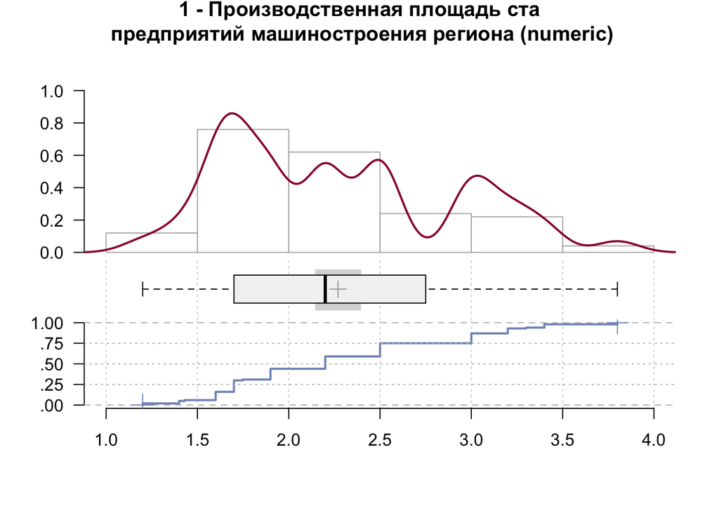

*Рис. 1. Гистограмма, ящичковая диаграмма и кумулята исследуемой переменной, выдаваемые функцией `Desc` пакета `DescTools`*

В результате мы получаем таблицу с кратким описанием признака. Также мы получаем расширенную дескриптивную статистику для каждого признака в датафрейме.

Также функция выдает три графика (рис. 1): а) гистограмму плотности и подогнанную с помощью непараметрических методов кривую плотности распределения, б) ящичковую диаграмму (`boxplot`) – по ней также можно судить о распределении признака, схожести его с нормальным распределением, но главное ее применение – выявление наличия экстремальных значений, в) кумуляту относительных частот.

Для удобства дальнейшего анализа запишем данные в вектор под именем `volume`, а также создадим переменную с объёмом выборки `n`:

```r
volume <- data[[1]]
n <- length(volume)
```

## 1.4. Гистограмма эмпирических частот

Построим сначала гистограмму частот. Для этого воспользуемся функцией `hist`:

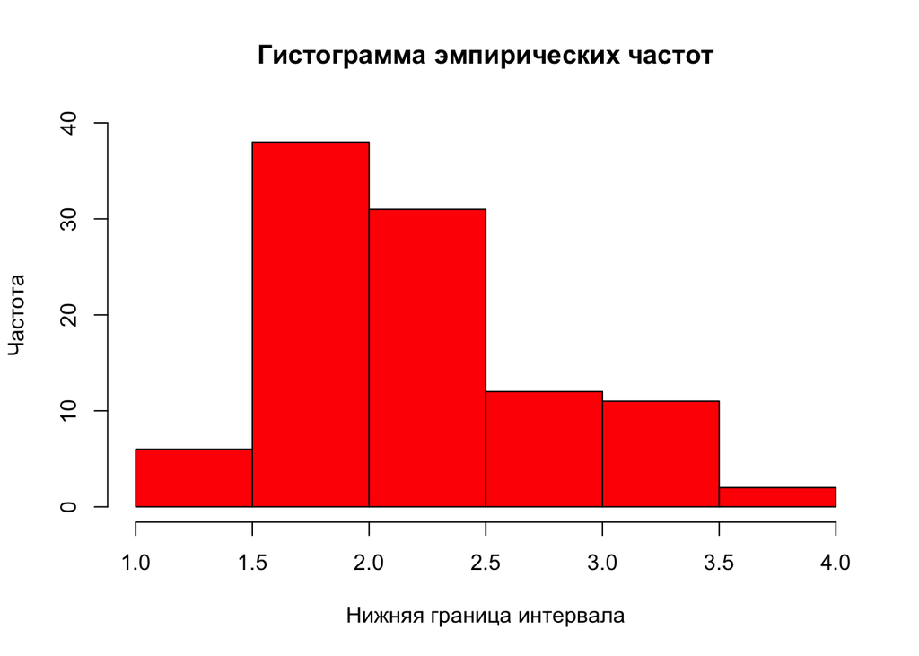

*Гистограмма эмпирических частот производственной площади ста предприятий машиностроения региона, построенная с помощью базовой функции `hist`*

```r
hist = hist(volume, freq = TRUE, col = 'red',
            breaks = 'sturges',
            xlab = 'Нижняя граница интервала',
            ylab = 'Частота', ylim = c(0, 40),
            main = 'Гистограмма эмпирических частот')
```

Для нанесения на гистограмму частот (рис. 2) теоретической кривой нормального распределения воспользуемся функцией `lines`, которая соединяет линией точки, координаты которых переданы в функцию аргументами. Где вектор из абсцисс мы сгенерируем функцией `seq`:

```r
x_values <- seq(from = min(volume)-0.1,
                to = max(volume)+0.1,length = 1000)
```

Значения теоретической кривой нормального распределения определим по формуле:
$$m_{iT} = P(a_i \le X \le b_i)
\cdot n = (F(b_i, \hat{\mu}, \hat{\sigma}) - F(a_i, \hat{\mu},
\hat{\sigma})) \cdot n \approx f(x_i, \hat{\mu}, \hat{\sigma}) \cdot h
\cdot n,$$
где $\hat{\mu}, \hat{\sigma}$ – оценки параметров, $h$ – ширина интервала гистограммы, $f(\cdot)$ – функция плотности нормального распределения, $F(\cdot)$ – функция распределения.

Ширину интервалов определим из полученного нами ранее результата вызова функции `hist`. Объект `hist` представляет из себя список, содержащий всю основную информацию о построенной гистограмме частот, первый элемент списка — список `breaks`, который содержит границы интервалов. Шаг мы определим как разницу между вторым и первым элементами этого списка (т.е. верхней и нижней границы первого интервала):

```r
h = unlist(hist['breaks'])[2]-unlist(hist['breaks'])[1]
```

Вектор из значений функции плотности нормального распределения в сгенерированных точках получим, воспользовавшись функцией `dnorm`, аргументами которой являются вектор из координат точек, значение функции плотности в которых нужно определить, средняя и стандартное отклонение совокупности:

```r
y_values <- dnorm(x_values, mean = mean(volume),
                  sd = sd(volume))*h*n
```

Итак, нанесем теоретическую кривую нормального закона на гистограмму частот (рис. 3):

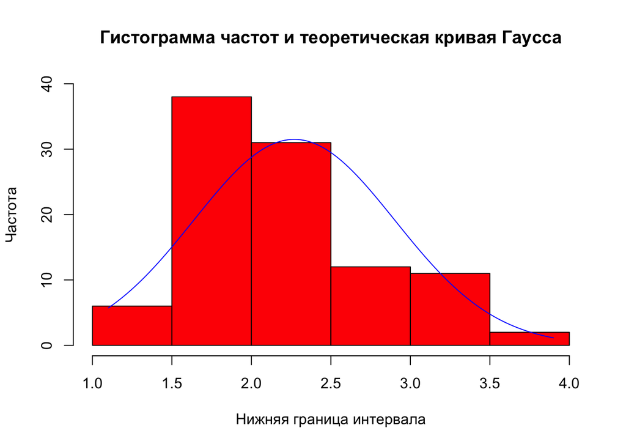

*Рис. 3. Гистограмма эмпирических частот производственной площади ста предприятий машиностроения региона и теоретическая кривая нормального распределения, построенные с помощью базовой функции `hist`*

```r
hist = hist(volume, freq = TRUE, col = 'red',
            breaks = 'sturges',
            xlab = 'Нижняя граница интервала',
            ylab = 'Частота', ylim = c(0, 40),
            main = 'Гистограмма частот и теоретическая кривая Гаусса')

lines(x_values, y_values, col = 'blue')
```

## 1.5. Интервальные оценки параметров нормального распределения

Для построения доверительных интервалов используем функции пакета `DescTools`.

Зададим сперва надежность, с которой будем строить все интервальные оценки параметров:

```r
gamma = 0.99 #надежность
```

Доверительный интервал для средней вычисляется функцией `MeanCI` (CI от Confidence Interval), аргументами которой необходимо передать вектор значений наблюдений выборки, по которой строится оценка, уровень надежности (`conf.level`, по умолчанию 0.95), если известно генеральное среднеквадратическое отклонение, то указать его значение, в противном случае, по умолчанию используется его выборочная оценка.

Предположим сначала, что нам известно значение генерального среднеквадратического отклонения $\sigma(X)=0.2$ , тогда доверительный интервал для средней строится следующим образом:

```r
MeanCI(volume, sd = 0.2, conf.level = gamma)
```

```
##     mean   lwr.ci   upr.ci
## 2.269800 2.218283 2.321317
```

Таким образом, при известной генеральной дисперсии интервальная оценка генеральной средней:
$$P(2.218283 \le
\mu \le 2.321317) = 0.99$$

В случае, если генеральная дисперсия неизвестна, доверительный интервал определяется следующим образом:

```r
MeanCI(volume, conf.level = gamma)
```

```
##     mean   lwr.ci   upr.ci
## 2.269800 2.103465 2.436135
```

$$P(2.103465 \le \mu \le 2.436135) =
0.99$$

Доверительный интервал для дисперсии можно найти, воспользовавшись функцией `VarCI`:

```r
VarCI(volume, conf.level = gamma)
```

```
##       var    lwr.ci    upr.ci
## 0.4010929 0.2856976 0.5970250
```

Получаем точечную оценку дисперсии $\hat{S}^2=0.4010929$, нижнюю и верхнюю границу доверительного интервала для дисперсии с надежностью 0.99:
$$P(0.2856976 \le \sigma^2 \le 0.5970250) =
0.99$$

Для среднеквадратического отклонения определим границы асимптотического доверительного интервала, написав код самостоятельно:
$$P\left(\frac{S \cdot \sqrt{2n}}{\sqrt{2n-3}
+ t} \le \sigma \le \frac{S \cdot \sqrt{2n}}{\sqrt{2n-3} - t}\right) =
\gamma = \Phi(t)$$

Квантиль нормального распределения определим функцией `qnorm`, аргументом которой передадим $1-\alpha/2$, где $\alpha=1-\gamma$.

```r
sdCI <- c(sd(volume)*sqrt(2*n)/(sqrt(2*n - 3) + qnorm(1-(1-gamma)/2)),
          sd(volume)*sqrt(2*n)/(sqrt(2*n - 3) - qnorm(1-(1-gamma)/2)))
names(sdCI) <- c('sd_min', 'sd_max')
sdCI
```

```
##    sd_min    sd_max
## 0.5391737 0.7815539
```

Таким образом, получаем асимптотический доверительный интервал для генерального среднего квадратического отклонения:
$$P(0.5391737 \le \sigma \le 0.7815539 ) =
0.99$$

## 1.6. Интервальные оценки вероятности (генеральной доли) биномиального распределения

### Задача 8 из ДКР1

##### Органы статистики региона хотят оценить долю населения, которая работает в частном секторе, во всем занятом населении. Предполагая, что число работников частных предприятий может быть описано биномиальным законом:

а) найти с надежностью 0.991 границы, в которых будет лежать доля жителей региона, работающих на частных предприятиях, если из 10 случайно отобранных занятых 5 работают на частных предприятиях;

В этом случае имеем дело с *выборкой небольшого объема*, поэтому используем *интервал Клоппера-Пирсона (Clopper-Pearson interval)* построения интервальной оценки вероятности.

Запишем данные условием задачи значения числа испытаний, числа успехов, надежности, с которой надо определить границы доверительного интервала;

Используем функцию `BinomCI` пакета `DescTools`, указав обязательные аргументы, требуемую надежность и метод *Клоппера-Пирсона*:

```r
n1 = 10 # число испытаний
m1 = 5 # число успехов
gamma1 = 0.991 # надежность
BinomCI(m1, n1, conf.level=gamma1, method = 'clopper-pearson')
```

```
##      est    lwr.ci    upr.ci
## [1,] 0.5 0.1252871 0.8747129
```

Получаем точечную оценку вероятности (`est`), нижнюю границу (`lwr.ci`) и верхнюю границу (`upr.ci`) доверительного интервала, построенного с надежностью 0.991, для доли жителей региона, работающих в частном секторе:
$$P(0.1252871 < p < 0.8747129) =
0.991$$

Стоит отметить, что интервальная оценка, полученная *методом Клоппера-Пирсона*, обладает наибольшей шириной. Сравним с интервалами, полученными другими методами.

В случае малого числа испытаний рекомендуют также использовать *интервалы Вилсона (Wilson) и Джеффриса*.

```r
BinomCI(m1, n1, conf.level=gamma1, method = 'wilson')
```

```
##      est    lwr.ci    upr.ci
## [1,] 0.5 0.1815783 0.8184217
```

Интервал Вилсона:
$$P(0.1815783 < p
< 0.8184217) = 0.991$$

```r
BinomCI(m1, n1, conf.level=gamma1, method = 'jeffreys')
```

```
##      est    lwr.ci    upr.ci
## [1,] 0.5 0.1548174 0.8451826
```

Интервал Джеффриса:
$$P(0.1548174 < p
< 0.8451826) = 0.991$$

Видно, что полученные такими методами интервалы уже, чем построенный нами ранее *интервал Клоппера-Пирсона*.

б) найти с надежностью 0.991 границы, в которых будет лежать доля жителей региона, работающих на частных предприятиях, если из 600 случайно отобранных занятых 384 работают на частных предприятиях;

Запишем данные условием задачи значения числа испытаний, числа успехов, надежности, с которой надо определить границы доверительного интервала;

Используем функцию `BinomCI` пакета `DescTools`, указав обязательные аргументы, требуемую надежность. В случае *выборки большого объема* для построения интервальной оценки вероятности часто используют нормальную аппроксимацию *(интервал Вальда)*:

```r
n2 = 600 # число испытаний
m2 = 384 # число успехов
gamma2 = 0.991 # надежность
BinomCI(m2, n2, conf.level=gamma2, method = 'wald')
```

```
##       est    lwr.ci    upr.ci
## [1,] 0.64 0.5888144 0.6911856
```

Получаем точечную оценку вероятности (`est`), нижнюю границу (`lwr.ci`) и верхнюю границу (`upr.ci`) доверительного интервала, построенного с надежностью 0.991:
$$P(0.5888144 < p < 0.6911856) =
0.991$$

Также при большом числе испытаний можно рассмотреть *интервал Агрести-Коула*, и в нашем случае он дал интервал меньшей ширины:

```r
BinomCI(m2, n2, conf.level=gamma1, method = 'agresti-coull')
```

```
##            est    lwr.ci    upr.ci
## [1,] 0.6384259 0.5874805 0.6893713
```

$$P(0.5874805 < p < 0.6893713) =
0.991$$